# Data Balancing for Liver Cancer Prediction

This script focuses on addressing class imbalance in the dataset for liver cancer prediction by applying various data balancing techniques. Class imbalance is a common challenge in medical datasets, where cases of liver cancer are significantly outnumbered by non-cancer cases. Properly handling this issue is essential to improve model performance and ensure reliable predictions.

**Key steps in this process:**

- Class distribution analysis to understand the extent of imbalance.
- Application of different balancing techniques, including SMOTE (Synthetic Minority Over-sampling Technique), oversampling, and undersampling.
- Evaluation of each balancing method using a classification model and key performance metrics such as Accuracy, Balanced Accuracy, Precision, Recall, and F1-Score.
- Selection of the best balancing strategy based on model performance, ensuring optimal results for liver cancer detection.

By implementing these techniques, the dataset will be optimized for Machine Learning models, improving their ability to detect liver cancer cases accurately while minimizing bias.

Author: Juan Armario  
Date: 2024

# Importing libraries

```python
import pandas as pd
import numpy as np

## Others
import warnings
import sys
from collections import Counter

## Plot
import seaborn as sns
import matplotlib
import matplotlib.pyplot as plt

# Suppress warnings for cleaner output
warnings.filterwarnings('ignore')

# Custom functions
sys.path.append("../../0. Scripts")
import model_balancing_functions as mbf

## Selection Models
from sklearn.model_selection import StratifiedKFold

## Models
from sklearn.ensemble import RandomForestClassifier

## Metrics
from sklearn.metrics import make_scorer, accuracy_score, balanced_accuracy_score, precision_score, recall_score, f1_score
from sklearn.metrics import confusion_matrix

## Dataset balancing
from imblearn.over_sampling import SMOTE, RandomOverSampler
from imblearn.under_sampling import NearMiss
```

# Loading Data

```python
# Original
original_train_df = pd.read_csv('../../0. Data/2. Training and Test/data_train_full_df.csv')

# Imputed dataset
transformed_train_df = pd.read_csv('../../0. Data/4. Transformed/transformed_removing_below_mean_train_df.csv')

transformed_train_copy_df = transformed_train_df.copy()

pd.set_option('display.max_columns', None)
```

```python
transformed_train_df.info()
```

```
<class 'pandas.core.frame.DataFrame'>
RangeIndex: 119495 entries, 0 to 119494
Data columns (total 13 columns):
 #   Column                  Non-Null Count   Dtype
---  ------                  --------------   -----
 0   liver_exitstat_sqrt     119495 non-null  float64
 1   filtered_f_log          119495 non-null  float64
 2   race7_log               119495 non-null  float64
 3   bmi_20c_raiz4           119495 non-null  float64
 4   sex_sqr                 119495 non-null  int64
 5   mortality_exitstat_log  119495 non-null  float64
 6   smokea_f_raiz4          119495 non-null  float64
 7   cig_stat_log            119495 non-null  float64
 8   bmi_50c_raiz4           119495 non-null  float64
 9   bmi_curc_raiz4          119495 non-null  float64
 10  preg_f_log              119495 non-null  float64
 11  agelevel_log            119495 non-null  float64
 12  fmenstr_log             119495 non-null  float64
dtypes: float64(12), int64(1)
memory usage: 11.9 MB
```

```python
target = original_train_df.liver_cancer
target.info()
```

```
<class 'pandas.core.series.Series'>
RangeIndex: 119495 entries, 0 to 119494
Series name: liver_cancer
Non-Null Count   Dtype
--------------   -----
119495 non-null  int64
dtypes: int64(1)
memory usage: 933.7 KB
```

```python
target.value_counts()
```

```
liver_cancer
0    119313
1       182
Name: count, dtype: int64
```

# Dataset balancing

Class imbalance is a critical issue in **liver cancer prediction,** as the number of non-cancer cases often vastly outweighs cancer cases. If left unaddressed, Machine Learning models tend to **favor the majority class,** leading to poor detection of liver cancer cases.

In this section, we apply **various data balancing techniques** to correct this imbalance. Methods such as **SMOTE (Synthetic Minority Over-sampling Technique), Random Oversampling, and Undersampling** are explored to determine which approach yields the best model performance. The effectiveness of these techniques is assessed through **cross-validation and classification metrics,** ensuring that the final model is **fair and unbiased** in predicting liver cancer.

```
Evaluating: Method = SMOTE
```

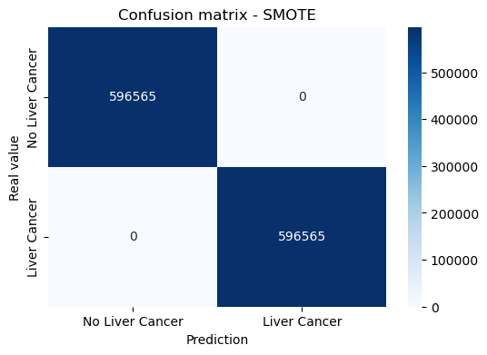

```
Evaluating: Method = Oversampling
```

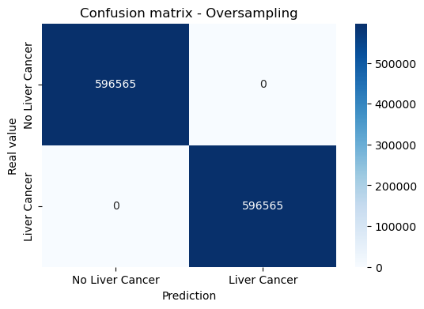

```
Evaluating: Method = Undersampling
```

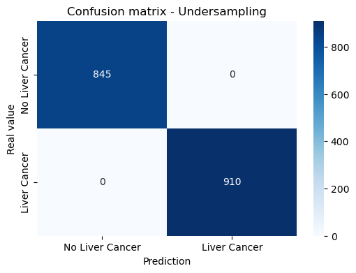

```
          Method                 Accuracy        Balanced Accuracy  \
0          SMOTE  : 1.00000 (+/- 0.00000)  : 1.00000 (+/- 0.00000)
1   Oversampling  : 1.00000 (+/- 0.00000)  : 1.00000 (+/- 0.00000)
2  Undersampling  : 1.00000 (+/- 0.00000)  : 1.00000 (+/- 0.00000)

       Precision (Class 1)         Recall (Class 1)       F1-Score (Class 1)
0  : 1.00000 (+/- 0.00000)  : 1.00000 (+/- 0.00000)  : 1.00000 (+/- 0.00000)
1  : 1.00000 (+/- 0.00000)  : 1.00000 (+/- 0.00000)  : 1.00000 (+/- 0.00000)
2  : 1.00000 (+/- 0.00000)  : 1.00000 (+/- 0.00000)  : 1.00000 (+/- 0.00000)
```

```python
X = transformed_train_copy_df
y = target

X = X.select_dtypes(include=['number'])
balancing_methods = {
    "SMOTE": lambda X, y: SMOTE(random_state=42).fit_resample(X, y),
    "Oversampling": lambda X, y: RandomOverSampler(random_state=42).fit_resample(X, y),
    "Undersampling": lambda X, y: NearMiss(version=3).fit_resample(X, y)
}

metrics = {
        "Accuracy": make_scorer(accuracy_score),
        "Balanced Accuracy": make_scorer(balanced_accuracy_score),
        "Precision (Class 1)": make_scorer(precision_score, pos_label=1),
        "Recall (Class 1)": make_scorer(recall_score, pos_label=1),
        "F1-Score (Class 1)": make_scorer(f1_score, pos_label=1)
    }

# Balancing methods evaluation
balance_results = mbf.evaluate_models_methods(balancing_methods, X, y, cv_splits=5, task_name="Method", metrics=metrics, include_conf_matrix=True)

print(balance_results)
```

```python
# Selecting the best method based on Recall (Clase 1)
best_method = balance_results.sort_values(by="Recall (Class 1)", ascending=False).iloc[0]

print("\n=== Best balacing method ===")
print(best_method)
```

```
=== Best balacing method ===
Method                                   SMOTE
Accuracy               : 1.00000 (+/- 0.00000)
Balanced Accuracy      : 1.00000 (+/- 0.00000)
Precision (Class 1)    : 1.00000 (+/- 0.00000)
Recall (Class 1)       : 1.00000 (+/- 0.00000)
F1-Score (Class 1)     : 1.00000 (+/- 0.00000)
Name: 0, dtype: object
```

# Aplying the best method

In this section, we implement the **best-performing balancing strategy** to create a final, **resampled dataset** that will be used for training Machine Learning models. This step ensures that our models are trained on a **well-balanced dataset,** improving their ability to correctly identify liver cancer cases while minimizing bias toward the majority class.

```python
X = transformed_train_copy_df
y = target

smote = SMOTE(random_state=42)
X_train_resampled, y_train_resampled = smote.fit_resample(X, y)
```

```python
y_train_resampled.shape
```

```
(238626,)
```

```python
y_train_resampled.value_counts()
```

```
liver_cancer
0    119313
1    119313
Name: count, dtype: int64
```

```python
X_train_resampled.shape
```

```
(238626, 13)
```

```python
balanced_train_df = pd.concat([X_train_resampled, y_train_resampled], axis=1)
balanced_train_df.head()
```

|  | liver_exitstat_sqrt | filtered_f_log | race7_log | bmi_20c_raiz4 | sex_sqr | mortality_exitstat_log | smokea_f_raiz4 | cig_stat_log | bmi_50c_raiz4 | bmi_curc_raiz4 | preg_f_log | agelevel_log | fmenstr_log | liver_cancer |
| --- | --- | --- | --- | --- | --- | --- | --- | --- | --- | --- | --- | --- | --- | --- |
| 0 | 2.828427 | 0.0001 | 0.0001 | 1.000000 | 1 | 0.693197 | 2.059767 | -9.210340 | 1.189207 | 1.189207 | -9.21034 | 0.000100 | -9.210340 | 0 |
| 1 | 2.449490 | 0.0001 | 0.0001 | 1.189207 | 4 | 0.000100 | 2.213364 | 0.000100 | 1.316074 | 1.414214 | 0.00010 | -9.210340 | 0.693197 | 0 |
| 2 | 2.828427 | 0.0001 | 0.0001 | 1.189207 | 4 | 1.098646 | 2.059767 | -9.210340 | 1.414214 | 1.414214 | 0.00010 | -9.210340 | 0.000100 | 0 |
| 3 | 2.236068 | 0.0001 | 0.0001 | 1.189207 | 1 | 0.000100 | 2.059767 | -9.210340 | 1.316074 | 1.189207 | -9.21034 | 0.693197 | -9.210340 | 0 |
| 4 | 2.828427 | 0.0001 | 0.0001 | 1.189207 | 4 | 0.000100 | 2.114743 | 0.693197 | 1.189207 | 1.189207 | 0.00010 | 1.098646 | 0.693197 | 0 |

```python
balanced_train_df.shape
```

```
(238626, 14)
```

```python
balanced_train_df.to_csv("../../0. Data/5. Balanced/balanced_train_df.csv", index=False)
```

```python
balanced_train_df.info()
```

```
<class 'pandas.core.frame.DataFrame'>
RangeIndex: 238626 entries, 0 to 238625
Data columns (total 14 columns):
 #   Column                  Non-Null Count   Dtype
---  ------                  --------------   -----
 0   liver_exitstat_sqrt     238626 non-null  float64
 1   filtered_f_log          238626 non-null  float64
 2   race7_log               238626 non-null  float64
 3   bmi_20c_raiz4           238626 non-null  float64
 4   sex_sqr                 238626 non-null  int64
 5   mortality_exitstat_log  238626 non-null  float64
 6   smokea_f_raiz4          238626 non-null  float64
 7   cig_stat_log            238626 non-null  float64
 8   bmi_50c_raiz4           238626 non-null  float64
 9   bmi_curc_raiz4          238626 non-null  float64
 10  preg_f_log              238626 non-null  float64
 11  agelevel_log            238626 non-null  float64
 12  fmenstr_log             238626 non-null  float64
 13  liver_cancer            238626 non-null  int64
dtypes: float64(12), int64(2)
memory usage: 25.5 MB
```